# Making the Most of Regression (or: Regression is Story-telling and Here’s How to Tell Your Story Well)

Steven V. Miller, svmiller.com

8 April 2021

Abstract

This is a lab script for [POST 8000](http://post8000.svmiller.com), a graduate-level quantitative methods for public policy class that I teach at Clemson University. It will not be the most sophisticated R-related write-up of mine—check [my blog](http://svmiller.com/blog) for those—but it should be useful for discussion around the associated R script for the week’s ‘lab’ session.

# Elsewhere on My Website

Some of what I write here is taken from my website. Please read these:

- [Age, Income, Partisanship, Racial Attitudes and the Trump Vote in 2016](http://svmiller.com/blog/2017/04/age-income-racism-partisanship-trump-vote-2016/)
- [How to Make the Most of Regression: Standardization and Post-Estimation Simulation](http://svmiller.com/blog/2020/04/post-estimation-simulation-trump-vote-midwest/)
- [Summarizing Ordinal Models with Simulation from a Multivariate Normal Distribution](http://svmiller.com/blog/2020/04/summarizing-ordinal-models-with-simulation-multivariate-normal/)

# R Packages/Data for This Session

We’ll be using a handful of packages for this lab session. You’ve seen `{tidyverse}` and `{stevedata}` before. `{tidyverse}` does most things workflow and `{stevedata}` is my data set vanity project that is nominally useful for teaching students like you. I’m *fairly* sure I’ve asked you to install `{modelr}` before, which is a great package for creating hypothetical data based on model parameters/inputs. The only one here that might be new is `{arm}`. Basically, some of my regression helper functions in `{stevemisc}` lean on stuff in `{arm}`. `get_sims()` is a wrapper around `arm::sim()` and `r2sd()` is a simpler version of `arm::rescale()`. However, I don’t like directly loading `{arm}` into stuff because `{arm}` has a big function clash with `{dplyr}` (part of `{tidyverse}`) over `select()`. Thus, `{stevemisc}` functions obviate the need to load `{arm}`, but emphasize the need to install `{arm}`. This function will make sure everything that should be installed is ultimately installed by way of CRAN.

```r
if_not_install <- function(packages) {
  new_pack <- packages[!(packages %in% installed.packages()[,"Package"])]
  if(length(new_pack)) install.packages(new_pack)
}

if_not_install(c("arm", "modelr", "stevedata", "tidyverse"))
```

Here, I might finally ask that you install `{stevemisc}`, if you have not already. While this script will load modular versions of the `r2sd()` function and `get_sims()` function, I think of this as a nifty package. It’s mine, after all, and I am nothing if not hopelessly, terminally vain. Perhaps I’m plotting an eponymous takeover of an entire programming language akin to what Cher did to pop music for the better part of 30 years. The majro difference between her and me is, well, she’s actually really good at what she does and I specialize exclusively in parlor tricks.

No matter, consider “un-commenting” (sic) this line of code and installing `{stevemisc}`. It’s not yet on CRAN, mostly because the CRAN gatekeepers aren’t happy with some of the “hackier” (i.e. lazier) things I have in this package. That’s on me, though.

```r
# devtools::install_github("svmiller/stevemisc")
```

Okie doke. Let’s load stuff. Do note that I asked you to install `{arm}`, but we won’t directly load it.

```r
library(tidyverse) # for everything
# library(stevemisc) # for get_sims() and r2sd(), devtools::install_github("svmiller/stevemisc")
library(stevedata)
library(modelr) # for data_grid()
```

If you load `{stevemisc}`, you won’t need to load these functions since these are automatically loaded in it. However, let’s copy those functions over for this script in case you’re having Curl issues on your end.

```r
get_sims <- function(model, newdata, nsim, seed) {
  if (missing(seed)) {

  } else {
    set.seed(seed)
  }
  modelsim <- arm::sim(model, n.sims = nsim)
  modmat <- model.matrix(terms(model), newdata)
  the_sims <- tibble(y = numeric(), sim = numeric())
  for (i in (1:nsim)) {
    if (is(model, "lm") == TRUE | is(model, "glm") == TRUE) {
      yi <- modmat %*% coef(modelsim)[i, ]
    } else {
      # assuming it's merMod
      yi <- modmat %*% coef(modelsim)$fixef[i, ]
    }
    simval <- rep(i, length(yi))
    hold_me <-  suppressMessages(as.data.frame(cbind(yi, simval)))
    the_sims <- rbind(the_sims, hold_me)
  }
  names(the_sims) <- c("y", "sim")
  the_sims <- as_tibble(the_sims)
  return(the_sims)
}

r2sd <- function(x, na = TRUE) {
  return((x - mean(x, na.rm = na)) / (2 * sd(x, na.rm = na)))
}
```

`TV16` comes from the 2016 Cooperative Congressional Election Study (CCES) data. It allows us to model the individual-level correlates of the self-reported Trump vote in 2016 using data from all 50 states, stratified on state population and other demographics. Importantly, there are more Californians than South Carolinians so data of this sort should (and here: does) reflect that. This is copy-pasted from another lab script that introduced these data.

Let’s use it to do an analysis, much like we did for the week on logistic regression. In this case, let’s subset the data to white voters in five Midwestern states: IN, MI, OH, PA, and WI. These are five states that Obama won in 2008 but Trump won in 2016. We’ll set aside, for the moment, concerns about spatial heterogeneity that we could otherwise address in a mixed effects model. I’m also going to create another variable that I had available in an earlier version of the data but had to take out for the “published” version of the data on CRAN. These are generation cutoffs using the age data (itself derived from the birth-year data explicitly asked by CCES but not included in the `TV16` data). For what it’s worth, “generations” are arbitrary constructs but these cutoffs come by way of Pew.

```r
TV16 %>%
  filter(racef == "White") %>%
  filter(state %in% c("Indiana","Ohio","Pennsylvania","Wisconsin","Michigan")) %>%
  mutate(birthyr = 2016 - age,
         generation = case_when(
           birthyr <= 1945 ~ "Greatest/Silent",
           between(birthyr, 1946, 1964) ~ "Baby Boomer",
           between(birthyr, 1965, 1980) ~ "Gen X",
           between(birthyr, 1981, 1996) ~ "Millennial",
           birthyr >= 1997 ~ "Gen Z"
  )) %>%
  select(uid:age, generation, everything()) -> Data
```

# Understanding (the Limitations) of the Regression Output

The whole point of this lab script is to show you how to make the most of regression (“MMR”). Regression is the workhorse tool for quantitative methods, and a lot of applications will lean on whether there is a “there there” for a particular independent variable of interest. However, you can no longer just apply a regression and be done with it. Regression is a form of story-telling. You, the researcher, have to tell your story well and in a way that is immediately accessible to people who will ideally be paying you good money to do this for them. Tell your story well.

Let’s assume we wanted to model the Trump vote in 2016 for white voters in these five states as a function of the respondent’s age, whether the respondent is a woman, whether the respondent has a four-year college diploma, the household income of the respondent, the partisanship of the respondent (D to R, 7-point scale), the respondent’s ideology (L to C, 5-point scale), whether the respondent says s/he is a born-again Christian, and an estimate of the respondent’s cognitive racism. All these should be ported over from the previous lab session, except for the cognitive racism variable. I mention a little bit about this variable in the 2017 post. Basically, DeSante and Smith’s “cognitive racism” measure emerged alongside another related one (“empathetic racism”) as improvements of the “racial resentment” battery that had been around for 30+ years to that point. Here, cognitive racism (on this latent scale of mine) comes by way of two survey items, one measuring whether a respondent acknowledges structural advantages afforded to white people that are not afforded to others and whether the respondent believes racism in the U.S. is rare. The concept around these two are a respondent’s awareness, or lack thereof, of systemic racism.

```r
M1 <- glm(votetrump ~ age + female + collegeed + famincr +
            pid7na + ideo + bornagain + lcograc,
          data = Data, family=binomial(link="logit"), na.action=na.exclude)

summary(M1)
```

```
##
## Call:
## glm(formula = votetrump ~ age + female + collegeed + famincr +
##     pid7na + ideo + bornagain + lcograc, family = binomial(link = "logit"),
##     data = Data, na.action = na.exclude)
##
## Deviance Residuals:
##     Min       1Q   Median       3Q      Max
## -3.3891  -0.3633  -0.0746   0.4050   2.9714
##
## Coefficients:
##              Estimate Std. Error z value Pr(>|z|)
## (Intercept) -6.112495   0.275324 -22.201  < 2e-16 ***
## age          0.018758   0.002978   6.299 2.99e-10 ***
## female       0.035444   0.089534   0.396   0.6922
## collegeed   -0.713984   0.104484  -6.833 8.29e-12 ***
## famincr     -0.012342   0.016220  -0.761   0.4467
## pid7na       0.749348   0.027242  27.507  < 2e-16 ***
## ideo         0.664195   0.061735  10.759  < 2e-16 ***
## bornagain    0.306570   0.102951   2.978   0.0029 **
## lcograc      1.264510   0.073569  17.188  < 2e-16 ***
## ---
## Signif. codes:  0 '***' 0.001 '**' 0.01 '*' 0.05 '.' 0.1 ' ' 1
##
## (Dispersion parameter for binomial family taken to be 1)
##
##     Null deviance: 8035.0  on 5802  degrees of freedom
## Residual deviance: 3484.6  on 5794  degrees of freedom
##   (3219 observations deleted due to missingness)
## AIC: 3502.6
##
## Number of Fisher Scoring iterations: 6
```

Nothing here is terribly surprising and any differences from the version of this we had in the logistic regression lab script may emerge from the inclusion of data from other states. Everything is significant beyond the coefficients for household income and gender. Look at this output and you might wonder if cognitive racism has the largest effect on the Trump vote. After all, it has the largest coefficient on an absolute scale. Wouldn’t that mean largest effect?

The answer here should be a clear “no.” It should be bloody obvious that partisanship is going to have the largest effect on the vote for Trump. Republicans vote for Republicans while not-Republicans are much less likely to vote for Republicans. However, that discrete 7-point scale is going to differ from the continuous scale of cognitive racism, which is bound between about -2 and 2. Basically: coefficients can’t be compared when they’re not on a common scale. The model, as it is, can be assessed for what parameters are statistically discernible from a counterclaim of zero effect, but this type of comparison is not appropriate.

# MMR: Scale by Two Standard Deviations

This situation is why Gelman recommends scaling anything that’s not binary by two standard deviations. The extent to which statistics textbooks introduce you scaling inputs, it’s almost always just a standard deviation. This is useful; the regression coefficient that emerges comes from inputs where 0 is the mean, communicates magnitude effects that might be more interesting, and it will make the intercept interpretable as well. However, scaling by two standard deviations does all that *and* has the helpful side effect of putting everything on a roughly common scale. Basically, scaling by two standard deviations results in variables that have a mean 0 and a standard deviation of .5. Binary variables, except for those with high “imbalance” (i.e. where pr(x == 1) is small), will also have standard deviations close to .5. This may not be perfect, but it’s really good and often close.

The `r2sd()` function in my `{stevemisc}` package will do this.

```r
Data %>%
  # Select the variables we want to mutate with mutate_at()
  # Apply the function to all of them and make a new column of them.
  mutate_at(vars("age", "famincr","pid7na","ideo", "lcograc"),
            list(z = ~r2sd(.))) %>%
  # ^ This will create a _z suffix for these new variables.
  # Let's use rename_at() to make those prefixes.
  rename_at(vars(contains("_z")),
            ~paste("z", gsub("_z", "", .), sep = "_") ) -> Data
```

Now, let’s re-run the model.

```r
M2 <- glm(votetrump ~ z_age + female + collegeed + z_famincr +
            z_pid7na + z_ideo + bornagain + z_lcograc,
          data = Data, family=binomial(link="logit"), na.action=na.exclude)

summary(M2)
```

```
##
## Call:
## glm(formula = votetrump ~ z_age + female + collegeed + z_famincr +
##     z_pid7na + z_ideo + bornagain + z_lcograc, family = binomial(link = "logit"),
##     data = Data, na.action = na.exclude)
##
## Deviance Residuals:
##     Min       1Q   Median       3Q      Max
## -3.3891  -0.3633  -0.0746   0.4050   2.9714
##
## Coefficients:
##             Estimate Std. Error z value Pr(>|z|)
## (Intercept) -0.16599    0.08159  -2.034   0.0419 *
## z_age        0.61777    0.09807   6.299 2.99e-10 ***
## female       0.03544    0.08953   0.396   0.6922
## collegeed   -0.71398    0.10448  -6.833 8.29e-12 ***
## z_famincr   -0.07410    0.09738  -0.761   0.4467
## z_pid7na     3.19193    0.11604  27.507  < 2e-16 ***
## z_ideo       1.44611    0.13441  10.759  < 2e-16 ***
## bornagain    0.30657    0.10295   2.978   0.0029 **
## z_lcograc    1.92768    0.11215  17.188  < 2e-16 ***
## ---
## Signif. codes:  0 '***' 0.001 '**' 0.01 '*' 0.05 '.' 0.1 ' ' 1
##
## (Dispersion parameter for binomial family taken to be 1)
##
##     Null deviance: 8035.0  on 5802  degrees of freedom
## Residual deviance: 3484.6  on 5794  degrees of freedom
##   (3219 observations deleted due to missingness)
## AIC: 3502.6
##
## Number of Fisher Scoring iterations: 6
```

It should be no surprise that putting everything on a common scale elevates the effect of partisanship. It will invariably be the largest predictor of vote choice in a national election like this. Interestingly, it looks like the effect of ideology is roughly similar in scale to cognitive racism as well. Also note the intercept means something as well. It tells us the probability of a Trump vote in the data for what amounts to a typical man (who is not a born-again Christian) is about .458. If you want to see how this works, recall our discussion of what is a logistic regression and wrap that intercept in a `plogis()` function.

# MMR: Create Some Quantities of Interest

Another way of telling your story well is to create some quantities of interest, based on the model output. Here, you can do anything you like and the quantities of interest you generate should be tailored to whatever it is you think is important to communicate on the model output. Let’s focus on the age variable as a place to start. Here: age is intuitively interval and communicating means from it makes sense. However, scaling age and using the scaled variable in a regression creates some confusion to the researcher as to what age corresponds with value of `z_age`. I want to show you how you can backtrack a little bit here.

First, let’s pitch a “quantity of interest” as the expected probability of voting for Trump by the typical age of each generation.

```r
Data %>%
  group_by(generation) %>%
  summarize(medianage = median(age)) %>% arrange(medianage)  %>% pull(medianage)  -> genmedage

genmedage
```

```
## [1] 19 29 44 60 76
```

Basically: the typical Gen Zer is 19 in this sample. The typical Millennial is 29. The typical Gen Xer is 44. The typical Boomer is 60. The typical Greatest or Silent is 76. Now, let’s find the z_ages that coincide with those because we included `z_age` in the model, not `age`.

```r
Data %>%
  # find ages that match what we just recorded in genmedage
  filter(age %in% genmedage) %>%
  # find the distinct z_ages that coincide with those, arrange, and extract as a vector.
  distinct(z_age) %>% arrange(z_age)  %>% pull(z_age) -> z_genmedage


genmedage
```

```
## [1] 19 29 44 60 76
```

```r
z_genmedage
```

```
## [1] -0.9198793 -0.6162403 -0.1607819  0.3250404  0.8108628
```

Now, let’s use `{modelr}`’s `data_grid()` to create a hypothetical set of observations with unique `z_ages`.

```r
Data %>%
  data_grid(.model = M2, z_age = z_genmedage, votetrump = 0) -> newdat


newdat
```

```
## # A tibble: 5 x 9
##    z_age votetrump female collegeed z_famincr z_pid7na  z_ideo bornagain
##    <dbl>     <dbl>  <dbl>     <dbl>     <dbl>    <dbl>   <dbl>     <dbl>
## 1 -0.920         0      1         0   0.00220   0.0254 -0.0393         0
## 2 -0.616         0      1         0   0.00220   0.0254 -0.0393         0
## 3 -0.161         0      1         0   0.00220   0.0254 -0.0393         0
## 4  0.325         0      1         0   0.00220   0.0254 -0.0393         0
## 5  0.811         0      1         0   0.00220   0.0254 -0.0393         0
## # … with 1 more variable: z_lcograc <dbl>
```

^ Here’s what this did. We created five rows of identical respondents. Basically, by default, `data_grid()` sets everything at the median observation unless you tell it otherwise. Note: the `get_sims()` function will want to see the DV as well, even if it’s irrelevant to the simulation. Just make sure a column name matching the DV is in there. So, what we did here was create a data grid from `Data`, where we leaned on the covariates in the model (`M2`) and created five rows of identical observations, save for `z_age`. In this case, `z_age` values are the median age for each of the five generations.

```r
newdat
```

```
## # A tibble: 5 x 9
##    z_age votetrump female collegeed z_famincr z_pid7na  z_ideo bornagain
##    <dbl>     <dbl>  <dbl>     <dbl>     <dbl>    <dbl>   <dbl>     <dbl>
## 1 -0.920         0      1         0   0.00220   0.0254 -0.0393         0
## 2 -0.616         0      1         0   0.00220   0.0254 -0.0393         0
## 3 -0.161         0      1         0   0.00220   0.0254 -0.0393         0
## 4  0.325         0      1         0   0.00220   0.0254 -0.0393         0
## 5  0.811         0      1         0   0.00220   0.0254 -0.0393         0
## # … with 1 more variable: z_lcograc <dbl>
```

It would help, for clarity sake, to say what is the actual age that coincides with z_age

```r
newdat %>% bind_cols(., tibble(age = genmedage)) %>%
  select(age, z_age, everything()) -> newdat
```

Now, let’s use the `get_sims()` function (from my `{stevemisc}` package) to create some simulations. These simulations, which lean on the `arm::sim()` function quietly, are drawn from a multivariate normal distribution where we’re relying on the model’s betas and covariance matrix to create some random draws as a posterior distribution, if you will. The `get_sims()` function is a wrapper that does this for you and creates a tidy output. Note: the function asks for, in order: the model (`M2`), the newdata of hypothetical observations (`newdat`), how many simulations you want (1,000 is considered default), and, finally, a reproducible seed. A reproducible seed is optional, but good hygiene.

```r
simsAge <- get_sims(M2, newdat, 1000, 8675309) # Jenny, I got your number.

simsAge %>%
  # Remember, these are logits. Let's inverse those real quick
  mutate(y = plogis(y)) -> simsAge

simsAge
```

```
## # A tibble: 5,000 x 2
##        y   sim
##    <dbl> <dbl>
##  1 0.320     1
##  2 0.371     1
##  3 0.454     1
##  4 0.546     1
##  5 0.634     1
##  6 0.324     2
##  7 0.371     2
##  8 0.447     2
##  9 0.530     2
## 10 0.612     2
## # … with 4,990 more rows
```

^ Notice this is 5,000 rows and two columns. The column `y` was a simulated natural logged odds of voting for Trump. Now it’s a probability. The `sim` column tells you which simulation it is. Notice how sim == 1 has five rows? Remember you had five rows of newdat? That means the first row in sim == 1 is the simulated logit of voting for Trump for an 19-year old. The second row in sim == 1 is the simulated logit of voting for Trump for a 29-year old, etc. The only caveat comes in noting two things: 1) There are 1,000 simulations, so sim == 1 is just one of those 1,000 for 19-year olds, etc. 2) You, the researcher, have to remember what you’re looking at.

But, you could make it easy for yourself to match those simulations to the values of x (here: `age`).

```r
newdat %>%
  # we really just want age
  select(age) %>%
  # Repeate these 5 rows however many times we did the simulations (here: 1000)
  slice(rep(row_number(), 1000))  %>%
  # bind them together
  bind_cols(simsAge, .) -> simsAge

simsAge # voila
```

```
## # A tibble: 5,000 x 3
##        y   sim   age
##    <dbl> <dbl> <dbl>
##  1 0.320     1    19
##  2 0.371     1    29
##  3 0.454     1    44
##  4 0.546     1    60
##  5 0.634     1    76
##  6 0.324     2    19
##  7 0.371     2    29
##  8 0.447     2    44
##  9 0.530     2    60
## 10 0.612     2    76
## # … with 4,990 more rows
```

^ even though the model technically used `z_age`, we just wanted to match `z_age` with `age`.

Now, let’s prepare a summary of this. Here’s where I reiterate that cool thing about simulations is that the world is your oyster. You can prepare this info any way you’d like. For example, here’s a raw summary.

```r
simsAge %>%
  # Remember, you want to summarize simulations. Group by the age (or value of whatever x you want)
  group_by(age) %>%
  # Let's create 95% intervals
  summarize(mean_y = mean(y),
            lwr = quantile(y, .025),
            upr = quantile(y, .975))
```

```
## # A tibble: 5 x 4
##     age mean_y   lwr   upr
## * <dbl>  <dbl> <dbl> <dbl>
## 1    19  0.344 0.293 0.400
## 2    29  0.387 0.342 0.433
## 3    44  0.455 0.421 0.490
## 4    60  0.530 0.494 0.565
## 5    76  0.603 0.559 0.646
```

You can also prepare this graphically.

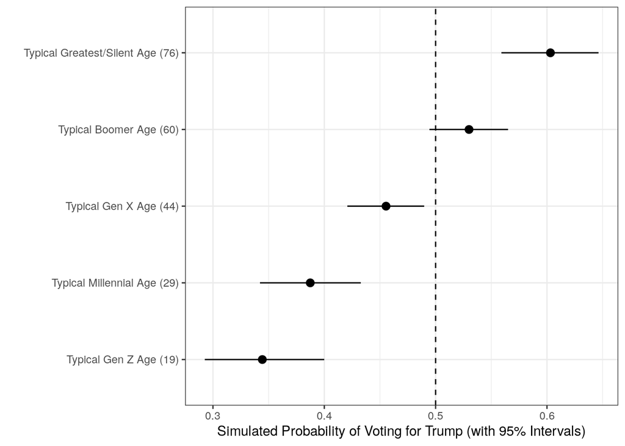

```r
simsAge %>%
  group_by(age) %>%
  summarize(mean_y = mean(y),
            lwr = quantile(y, .025),
            upr = quantile(y, .975)) %>%
  # ^ same basic summary
  # Below: treat age as a factor. Trust me, it'll be more readable
  ggplot(.,aes(as.factor(age), mean_y, ymin=lwr, ymax=upr)) +
  theme_bw() +
  # geom_pointrange() creates point summary with those ymin and ymax
  geom_pointrange() +
  geom_hline(yintercept = .5, linetype = "dashed") +
  scale_x_discrete(labels = c("Typical Gen Z Age (19)", "Typical Millennial Age (29)",
                              "Typical Gen X Age (44)", "Typical Boomer Age (60)",
                              "Typical Greatest/Silent Age (76)")) +
  coord_flip() +
  labs(x = "", y = "Simulated Probability of Voting for Trump (with 95% Intervals)")
```

There are any number of things you can do here, but simulation by way of multivariate normal offers so many cool opportunities to summarize your model output in a way that’s immediately more intuitive to more people than just shoving a regression table in the reader’s face and expecting them to fill in the blanks.

You could also do this to do more thorough comparison/evaluation of competing coefficients. I did something similar in my [recent publication in *Social Science Journal*](http://svmiller.com/research/economic-anxiety-ethnocentrism-immigration-1992-2017/) about what has the larger magnitude effects on attitudes about immigration. In this application, though, I’m piqued by this potential claim that the effect of cognitive racism in explaining the Trump vote might be equivalent to the effect of ideology (if not partisanship). Model 2 at least implied that, or suggested it, with standardized coefficients.

How might we tease that out in simulation? The process would be similar. First, let’s get a sense of what our `z_ideo` values are in relation to our `ideo` values.

```r
Data %>%
  distinct(ideo, z_ideo) %>% na.omit %>% arrange(ideo)
```

```
## # A tibble: 5 x 2
##    ideo  z_ideo
##   <dbl>   <dbl>
## 1     1 -0.958
## 2     2 -0.499
## 3     3 -0.0393
## 4     4  0.420
## 5     5  0.879
```

^ this grabbed my eye. Notice the effect of going from a 2 to 4 is almost a change of two standard deviations? i.e. the difference between the two is almost 1. So: about 2 SDs. For those curious, a 2 is a “liberal” and a 4 is a “conservative.” Let’s pull those.

```r
Data %>% filter(ideo %in% c(2,4)) %>%
  distinct(z_ideo) %>%  arrange(z_ideo) %>% pull(z_ideo) -> z_ideos
```

I’m going to have to get creative with these newdats, but let’s create one for these two ideology values.

```r
Data %>%
  data_grid(.model = M2, z_ideo = z_ideos, votetrump = 0) -> newdat_ideo
```

The difference is almost 1, but let’s be precise

```r
diffzideo <- z_ideos[2] - z_ideos[1]

diffzideo
```

```
## [1] 0.9185942
```

Now, let’s create another data frame. This will be for hypothetical values of `z_lcograc`. One is zero (i.e. the mean). The other value is the difference in scale on ideology. Because `lcograc` is interval/continuous, this is a plausible value by itself and coincides with an identical increase in scale of ideology.

```r
Data %>%
  data_grid(.model = M2, z_lcograc = c(0,diffzideo), votetrump = 0) %>% # let's just bind the two together while we're here.
  bind_rows(newdat_ideo, .) -> newdat
```

^ so, in this object, the first two rows have different values of ideology. Everything else is constant. In the second two rows, there are different values of cognitive racism. Everything else is constant. Always remember what you’re doing at every step of the way.

Now, let’s get some simulations.

```r
simsIR <- get_sims(M2, newdat, 1000, 8675309)

simsIR
```

```
## # A tibble: 4,000 x 2
##          y   sim
##      <dbl> <dbl>
##  1 -0.678      1
##  2  0.633      1
##  3 -0.0516     1
##  4  1.73       1
##  5 -0.776      2
##  6  0.641      2
##  7 -0.0967     2
##  8  1.70       2
##  9 -0.660      3
## 10  0.655      3
## # … with 3,990 more rows
```

^ We could add in the newdat frame like we did previously, but that’s less useful in this case, I think. Remember the second point I mentioned above about your sims. You gotta know what you’re looking at. So let’s manually create an identifier.

```r
simsIR %>%
  mutate(indicator = rep(c("Ideology Change (L to C)","Ideology Change (L to C)",
                           "Identical Cognitive Racism Change","Identical Cognitive Racism Change"), 1000)) -> simsIR
```

Now, do some group_by summarizing. Let’s do first differences here instead.

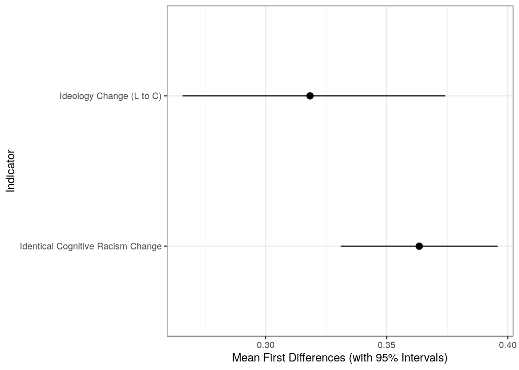

```r
simsIR %>%
  # Convert y to prob
  mutate(y = plogis(y)) %>%
  # Group by sims as well to get first diffs.
  group_by(sim, indicator) %>%
  mutate(fd = y - lag(y)) %>%
  na.omit %>% #  drop NAs, which are basically the lower category. we have what we need
  # practice safe group_by
  ungroup() %>%
  # group_by() again
  group_by(indicator) %>%
  summarize(meanfd = mean(fd),
            lwr = quantile(fd, .025),
            upr = quantile(fd, .975)) %>%
  ggplot(.,aes(indicator, meanfd, ymin=lwr, ymax=upr)) +
  theme_bw() +
  geom_pointrange() + coord_flip() +
  labs(x = "Indicator",
       y = "Mean First Differences (with 95% Intervals)")
```

^ takeaway: as a point estimate, cognitive racism is having a larger magnitude effect than ideology when precisely adjusted for scale. The point estimate is bigger and, incidentally, it’s lower bound is above the *point* estimate for ideology. However, ideology’s upper bound overlaps cognitive racism considerably. It’s estimated first difference is more diffuse. You can’t say for certain that cognitive racism had a larger effect, but the estimate is larger and is more precise.

While you should aspire to tailor the quantities of interest toward the story you want to tell to your intended audience (typically regarding some variable of interest), again, you can do anything you want here. For example, we know other values vary by age as well. So, it’s not quite a simple case of just “holding everything constant” and allowing just one thing to vary. What if you wanted to do a more general assessment of varying patterns of the Trump vote by reference to the “generations” data we created? Here’s how you’d do that.

```r
Data %>%
  group_by(generation) %>%
  summarize_at(vars(all.vars(M2$formula)[2:9]), ~list(median(., na.rm=T))) %>%
  unnest(generation:ncol(.)) %>%
  arrange(z_age) %>%
  mutate(votetrump = 0) -> newdat_generation


get_sims(M2, newdat_generation, 1000, 8675309) %>%
  mutate(y = plogis(y),
         generation = fct_inorder(rep(c("Gen Z", "Millennial",
                                        "Gen X", "Baby Boomer",
                                        "Greatest/Silent"), 1000))) %>%
  group_by(generation) %>%
  summarize(mean_y = mean(y),
            lwr = quantile(y, .025),
            upr = quantile(y, .975))
```

```
## # A tibble: 5 x 4
##   generation      mean_y   lwr   upr
## * <fct>            <dbl> <dbl> <dbl>
## 1 Gen Z            0.278 0.229 0.330
## 2 Millennial       0.352 0.306 0.397
## 3 Gen X            0.487 0.452 0.522
## 4 Baby Boomer      0.530 0.494 0.565
## 5 Greatest/Silent  0.606 0.561 0.650
```

You could also plot it as well.

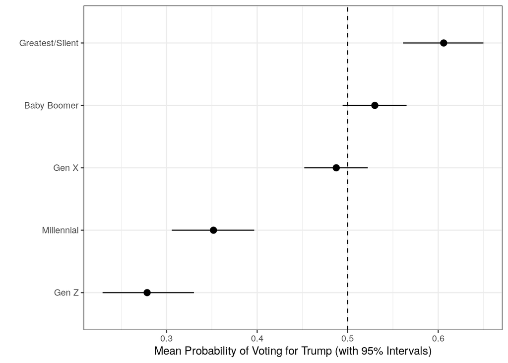

```r
get_sims(M2, newdat_generation, 1000, 8675309) %>%
  mutate(y = plogis(y),
         generation = fct_inorder(rep(c("Gen Z", "Millennial",
                                        "Gen X", "Baby Boomer",
                                        "Greatest/Silent"), 1000))) %>%
  group_by(generation) %>%
  summarize(mean_y = mean(y),
            lwr = quantile(y, .025),
            upr = quantile(y, .975)) %>%
  ggplot(.,aes(generation, mean_y, ymin=lwr, ymax=upr)) +
  geom_hline(yintercept = .5, linetype = "dashed") +
  theme_bw() +
  coord_flip() +
  geom_pointrange() +
  labs(y = "Mean Probability of Voting for Trump (with 95% Intervals)",
       x = "")
```

What about the probability of a Trump vote for each combination of college-educated and self-identified “born again” Christian?

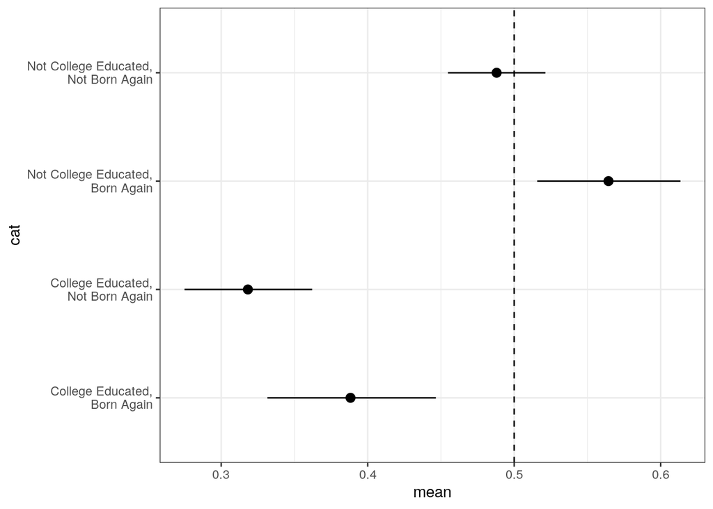

```r
Data %>%
  data_grid(.model = M2,
            votetrump = 0,
            collegeed = c(0, 1),
            bornagain = c(0, 1)) -> newdat_colborn

sims_colborn <- get_sims(M2, newdat_colborn, 1000, 8675309)

newdat_colborn %>%
  # we really just want these two
  select(collegeed, bornagain) %>%
  # Repeate these 5 rows however many times we did the simulations (here: 1000)
  slice(rep(row_number(), 1000)) %>%
  bind_cols(., sims_colborn) %>%
  mutate(y = plogis(y)) %>%
  # create categories
  mutate(colcat = ifelse(collegeed == 0, "Not College Educated", "College Educated"),
         bornagaincat = ifelse(bornagain == 0, "Not Born Again", "Born Again"),
         cat = paste0(colcat, ",\n", bornagaincat)) %>%
  # summarize
  group_by(cat) %>%
  summarize(mean = mean(y),
            lwr = quantile(y, .025),
            upr = quantile(y, .975)) %>%
  ggplot(.,aes(cat, y=mean, ymin=lwr, ymax=upr)) +
  geom_hline(yintercept = 0.5, linetype="dashed") +
  coord_flip() +
  theme_bw() +
  geom_pointrange()
```

What you do here is up to you. I don’t know the story you want to tell, but I think these to be the most accessible tools to tell your story.